# Exploring Stability and Predictive Power of Scoring Statistics in the NBA

Comparing box score statistics and ShotQuality expectation metrics to understand the randomness of single game samples to improve prediction accuracy

Myles Thomas https://github.com/MylesThomas (ShotQuality)https://shotquality.com  
December 12, 2021

As we approach the new year, in the 2021-2022 NBA Season there have been over 107,587 shots taken. In a make or miss league, scoring performance has a huge influence on game outcomes and also on advanced metrics like points per possession (PPP) and true shooting percentage (TS%). One of the reasons that many highly regarded power ranking systems had the 2020 New York Knicks rated lower was due to their “luckiness” with opponent 3-point percentage. Are certain scoring statistics a reflection of a team’s underlying talent/skill, or are they simply random noise that will fluctuate game-by-game and cannot predict future performance? If we find that certain metrics are stable for teams and/or players throughout a season, we can incorporate scoring regression to make better predictions out of sample.

# Exploring stability of box score statistics

Single game performances tend to be noisy, especially when looking at individual statistics. Using the mean values for each box score statistic for each individual game, we will bucket each team and box score statistic into 5 game rolling windows and find the correlation across teams during this season.

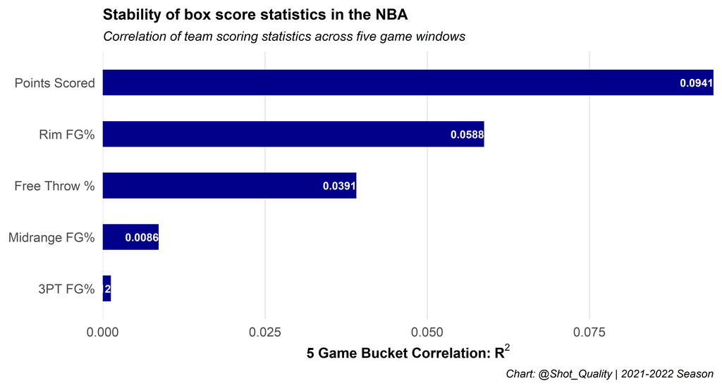

# Exploring stability of ShotQuality metrics

ShotQuality expectation variables were created to derive process-based insights on the quality of possessions. This takes into account the individual player’s shot making ability when computing, so these metrics should have better stability and robustness to the noise of a lucky game, right? Let’s repeat the analysis using the SQ expectations.

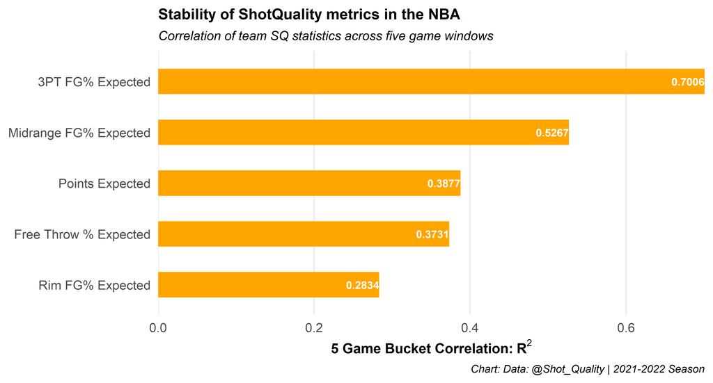

Wow! The game to game correlation between the ShotQuality metrics is far superior to that of ordinary box score statistics. Putting the correlations on the same axis should further hammer this point home.

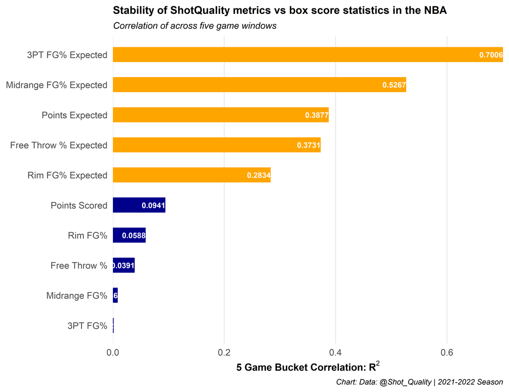

We now know that generally, box score statistics are extremely fluky and unstable metrics for teams, especially for shooting percentages. Given this information, how can we take this into account for prediction? If we are going to predict future game outcomes, it might be smart to create a weighted ‘game grade’ model measured by its `RSQ` to future points scored (ie, out of sample point differential).

# Descriptive vs Predictive

In this analysis, a statistic’s ability to describe the final score of a game is measured by its correlation to the same game’s point differential. A game grade’s ability to predict future performance is measured by its RSQ to future point differential (aka out of sample point differential).

The out of sample RSQ is measured across three rolling windows: 1 game, 4 games, and 8 games. The windows are equally sized (not rolling, expanding, or dynamically moving windows) and constrained to games from this season. For example, a team approaching game number 5 has 4 preceding games (1, 2, 3 and 4) that are used to make a prediction about the team’s next 4 games (games 5, 6, 7, and 8). Those games (5, 6, 7, and 8) are used to predict the next 4 games (9, 10, 11 and 12), and so on:

|  | Point Differential | Points Observed | Points SQ | 3PT % Observed | 3PT % SQ | Midrange % Observed | Midrange % SQ | rim | pred_rim | FT % Observed | FT % SQ |
| --- | --- | --- | --- | --- | --- | --- | --- | --- | --- | --- | --- |
| Correlation to Same Game PD | 1.000 | 0.336 | 0.100 | 0.209 | 0.068 | 0.033 | 0.035 | 0.109 | 0.095 | 0.015 | 0.011 |
| OoS RSQ to PD (1 Game Window) | 0.015 | 0.005 | 0.018 | 0.001 | 0.027 | 0.001 | 0.012 | 0.010 | 0.020 | 0.001 | 0.002 |
| OoS RSQ to PD (4 Game Window) | 0.096 | 0.026 | 0.085 | 0.014 | 0.127 | 0.003 | 0.056 | 0.027 | 0.073 | 0.009 | 0.023 |
| OoS RSQ to PD (8 Game Window) | 0.147 | 0.027 | 0.145 | 0.005 | 0.176 | 0.010 | 0.071 | 0.059 | 0.139 | 0.018 | 0.030 |

Chart: Data: @Shot_Quality | 2021-2022 Season

# Wrapping up

The main objective of this post was to look at which scoring metrics we can expect to perform similarly from night to night, and which ones are ultimately random. Understanding which metrics random (and filtering them out from the ‘game score’) and which are stable allows us to better rank the performance of teams on a given night.

We also looked at how well each of these metrics could predict the point differential of a future game, which is where the ShotQuality metrics outperformed the regular box score statistics. This goes to show that ShotQuality metrics account for game to game randomness much better than box score statistics and should be used to assess team performance going forward. In the future, we can investigate how ShotQuality metrics can be used to predict the outcomes of future games.

## Acknowledgments

Distill for R Markdown builds on the work of many individuals and projects. [Shan Carter](https://github.com/shancarter), [Ludwig Schubert](https://github.com/ludwigschubert), and [Christopher Olah](https://github.com/colah) created the Distill web framework. [John MacFarlane](https://github.com/jgm) created the Pandoc universal markup converter. [Davide Cervone](https://github.com/dpvc) and [Volker Sorge](https://github.com/zorkow) created the MathJax library for rendering mathematical notation on the web. [Mike Bostock](https://github.com/mbostock) created the D3 library for producing dynamic, interactive data visualizations for the web. We are grateful for the spirit of generosity that moved these individuals to create high-quality open source software for the benefit of all.

## Corrections

If you see mistakes or want to suggest changes, please [create an issue](https://github.com/MylesThomas/nba-scoring-stability-predictive-power/issues/new) on the source repository.

## Acknowledgments

Text and figures are licensed under Creative Commons Attribution [CC BY 4.0](https://creativecommons.org/licenses/by/4.0/). Source code is available at https://github.com/MylesThomas/nba-scoring-stability-predictive-power, unless otherwise noted. The figures that have been reused from other sources don’t fall under this license and can be recognized by a note in their caption: “Figure from …”.